# JLS: Preemptive notes from student

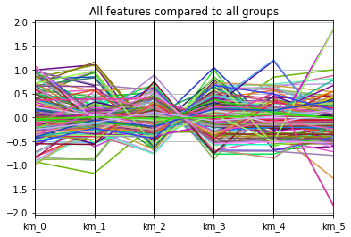

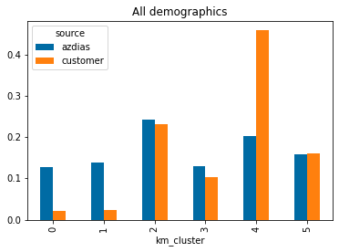

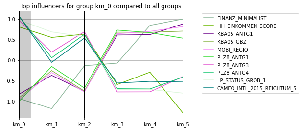

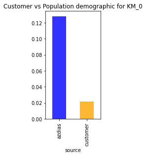

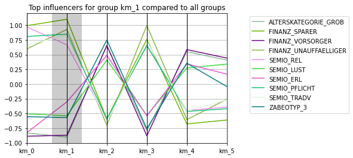

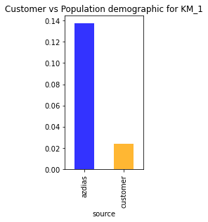

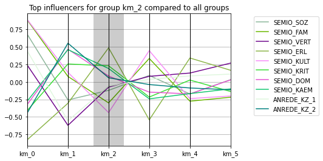

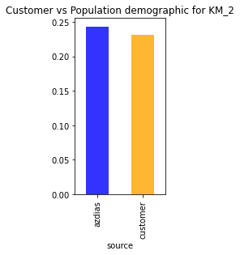

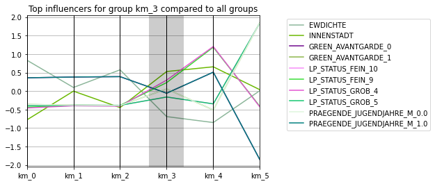

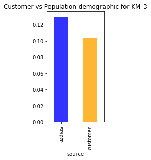

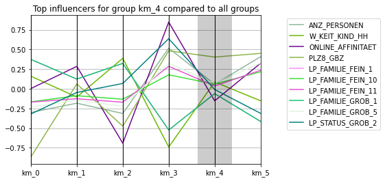

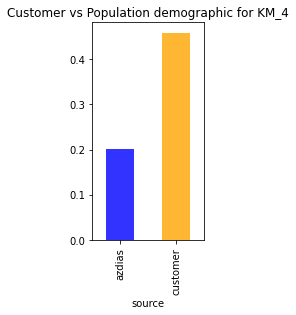

[2 more figures not shown]

```python
plot_group_g(cluster_ratios)
for g in range(6):
    plot_group_g(cluster_ratios, g)
```

Cool! Limiting the features to the most influential and plotting across groups, makes it easier to visualize the ties between our clusters. Take a look at the graphs for groups four and one especially. Then read more below, and maybe come back for another look.

```python
# What kinds of people are part of a cluster that is overrepresented in the
# customer data compared to the general population?
```

The customer's highest demographic was **group four**, we haven't analyzed it earlier so let's look now!.

```python
get_component_info(pca, 4).head(10)
```

|  | information_level | weight | definition | dim_translation | codes[0] | codes[-1] | type |
| --- | --- | --- | --- | --- | --- | --- | --- |
| ANZ_PERSONEN | household | 0.302161 | Number of adults in household | None | None | None | numeric |
| LP_FAMILIE_GROB_5 | person | 0.257051 | Family type, rough scale | None | 1 : single (maps to 1 in fine scale) | 5 : multiperson household (maps to 9-11 in fine scale) | categorical |
| LP_FAMILIE_FEIN_10 | person | 0.19399 | Family type, fine scale | None | 1 : single | 11 : multi-generational household | categorical |
| ONLINE_AFFINITAET | region_rr1 | 0.141081 | Online affinity | None | 0 : none | 5 : highest | ordinal |
| LP_FAMILIE_FEIN_11 | person | 0.137958 | Family type, fine scale | None | 1 : single | 11 : multi-generational household | categorical |
| FINANZTYP_6 | person | 0.133758 | Most descriptive financial type for individual | None | 1 : low financial interest (MINIMALIST) | 6 : inconspicuous (UNAUFFAELLIGER) | categorical |
| KKK | region_rr1 | 0.13317 | Purchasing power in region | None | 1 : very high | 4 : low | ordinal |
| CAMEO_INTL_2015_REICHTUM_5 | None | 0.125381 | No definition found | None | None | None | None |
| LP_FAMILIE_GROB_4 | person | 0.114256 | Family type, rough scale | None | 1 : single (maps to 1 in fine scale) | 5 : multiperson household (maps to 9-11 in fine scale) | categorical |
| OST_WEST_KZ_O | building | 0.109848 | Building location via former East / West Germany (GDR / FRG) | None | O : East (GDR) | W : West (FRG) | categorical |

```python
get_component_info(pca, 4).tail(10)
```

|  | information_level | weight | definition | dim_translation | codes[0] | codes[-1] | type |
| --- | --- | --- | --- | --- | --- | --- | --- |
| KBA13_ANZAHL_PKW | macrocell_plz8 | -0.093913 | Number of cars in the PLZ8 region | None | None | None | numeric |
| FINANZ_UNAUFFAELLIGER | person | -0.095081 | Financial typology, for each dimension: | UNAUFFAELLIGER: inconspicuous | 1 : very high | 5 : very low | ordinal |
| LP_STATUS_FEIN_4 | person | -0.099122 | Social status, fine scale | None | 1 : typical low-income earners | 10 : top earners | categorical |
| LP_STATUS_FEIN_3 | person | -0.099683 | Social status, fine scale | None | 1 : typical low-income earners | 10 : top earners | categorical |
| OST_WEST_KZ_W | building | -0.109848 | Building location via former East / West Germany (GDR / FRG) | None | O : East (GDR) | W : West (FRG) | categorical |
| PLZ8_GBZ | macrocell_plz8 | -0.120291 | Number of buildings within the PLZ8 region | None | 1 : less than 60 buildings | 5 : more than 449 buildings | ordinal |
| LP_STATUS_GROB_2 | person | -0.148975 | Social status, rough scale | None | 1 : low-income earners (maps to 1-2 in fine scale) | 5 : top earners (maps to 10 in fine scale) | categorical |
| W_KEIT_KIND_HH | household | -0.253993 | Likelihood of children in household | None | 1 : most likely | 6 : very unlikely | ordinal |
| LP_FAMILIE_GROB_1 | person | -0.342447 | Family type, rough scale | None | 1 : single (maps to 1 in fine scale) | 5 : multiperson household (maps to 9-11 in fine scale) | categorical |
| LP_FAMILIE_FEIN_1 | person | -0.342447 | Family type, fine scale | None | 1 : single | 11 : multi-generational household | categorical |

**Group four** appears to be based on people who live in family settings with kids in rough neighborhoods. They aren't normally high earners.

The customer should spend most of their time working with this group.

Based on the groupings I think it makes sense for the company to spend some time exploring this demographic, but not at the cost of working with group 4.

```python
# What kinds of people are part of a cluster that is underrepresented in the
# customer data compared to the general population?

get_component_info(pca, 5)
```

|  | information_level | weight | definition | dim_translation | codes[0] | codes[-1] | type |
| --- | --- | --- | --- | --- | --- | --- | --- |
| CAMEO_INTL_2015_REICHTUM_4 | None | 0.401458 | No definition found | None | None | None | None |
| CAMEO_DEUG_2015_6 | microcell_rr4 | 0.350287 | German CAMEO: Wealth / Life Stage Typology, rough scale | None | 1 : upper class | 9 : urban working class | categorical |
| CAMEO_DEU_2015_6B | microcell_rr4 | 0.291616 | German CAMEO: Wealth / Life Stage Typology, detailed scale | None | 1A : Work-Life-Balance | 9E : Socking Away | categorical |
| CAMEO_INTL_2015_LEBENSSTATUS_3 | None | 0.242118 | No definition found | None | None | None | None |
| CAMEO_DEUG_2015_7 | microcell_rr4 | 0.147945 | German CAMEO: Wealth / Life Stage Typology, rough scale | None | 1 : upper class | 9 : urban working class | categorical |
| ... | ... | ... | ... | ... | ... | ... | ... |
| CAMEO_INTL_2015_LEBENSSTATUS_4 | None | -0.156028 | No definition found | None | None | None | None |
| CAMEO_DEUG_2015_4 | microcell_rr4 | -0.170479 | German CAMEO: Wealth / Life Stage Typology, rough scale | None | 1 : upper class | 9 : urban working class | categorical |
| CAMEO_DEUG_2015_9 | microcell_rr4 | -0.183407 | German CAMEO: Wealth / Life Stage Typology, rough scale | None | 1 : upper class | 9 : urban working class | categorical |
| CAMEO_INTL_2015_REICHTUM_2 | None | -0.188626 | No definition found | None | None | None | None |
| CAMEO_INTL_2015_REICHTUM_5 | None | -0.213 | No definition found | None | None | None | None |

213 rows × 7 columns

For reference, we engineered the following categories, and since they aren't directly in the dictionary, here are the mappings.

- CAMEO_INTL_2015_REICHTUM_4 - "Less Affluent Households"
- CAMEO_INTL_2015_REICHTUM_2 - "Prosperous Households"
- CAMEO_INTL_2015_REICHTUM_5 - "Poorer Households

Group five is is another wealth based grouping. It has a large number of working class and "socking away" members. It's made up of less affluent people but not the poorest. It looks like a probable good fit for "working middle class" with mixed elements of wealth.

### Discussion 3.3: Compare Customer Data to Demographics Data

They aren't likely to see enormous success with the general middle class in standard neighborhoods.

> Congratulations on making it this far in the project! Before you finish, make sure to check through the entire notebook from top to bottom to make sure that your analysis follows a logical flow and all of your findings are documented in **Discussion** cells. Once you've checked over all of your work, you should export the notebook as an HTML document to submit for evaluation. You can do this from the menu, navigating to **File -> Download as -> HTML (.html)**. You will submit both that document and this notebook for your project submission.

Return to notebook start

```python
# Notebook Runtime:
nb_end = time.time()
nb_final_time = nb_end - nb_start
print(f"This notebook run completed in {nb_final_time} seconds. ({nb_final_time/60} min)")
```

```
This notebook run completed in 486.58664417266846 seconds. (8.109777402877807 min)
```

## JLS: Python Development Environment

### Directly installed modules

```
jupyter==1.0.0
pandas==1.4.3
scikit-learn==1.1.1
matplotlib==3.5.2
seaborn==0.11.2
ipython==8.4.0
ipykernel==6.15.0
```

### Full dependency list

See also requirements.txt

```
argon2-cffi==21.3.0
argon2-cffi-bindings==21.2.0
asttokens==2.0.5
attrs==21.4.0
backcall==0.2.0
beautifulsoup4==4.11.1
bleach==5.0.0
cffi==1.15.0
cycler==0.11.0
debugpy==1.6.0
decorator==5.1.1
defusedxml==0.7.1
entrypoints==0.4
executing==0.8.3
fastjsonschema==2.15.3
fonttools==4.33.3
ipykernel==6.15.0
ipython==8.4.0
ipython-genutils==0.2.0
ipywidgets==7.7.1
jedi==0.18.1
Jinja2==3.1.2
joblib==1.1.0
jsonschema==4.6.0
jupyter==1.0.0
jupyter-client==7.3.4
jupyter-console==6.4.4
jupyter-core==4.10.0
jupyterlab-pygments==0.2.2
jupyterlab-widgets==1.1.1
kiwisolver==1.4.3
MarkupSafe==2.1.1
matplotlib==3.5.2
matplotlib-inline==0.1.3
mistune==0.8.4
nbclient==0.6.4
nbconvert==6.5.0
nbformat==5.4.0
nest-asyncio==1.5.5
notebook==6.4.12
nptyping==2.2.0
numpy==1.23.0
packaging==21.3
pandas==1.4.3
pandocfilters==1.5.0
parso==0.8.3
pexpect==4.8.0
pickleshare==0.7.5
Pillow==9.1.1
prometheus-client==0.14.1
prompt-toolkit==3.0.29
psutil==5.9.1
ptyprocess==0.7.0
pure-eval==0.2.2
pycparser==2.21
Pygments==2.12.0
pyparsing==3.0.9
pyrsistent==0.18.1
python-dateutil==2.8.2
pytz==2022.1
pyzmq==23.2.0
qtconsole==5.3.1
QtPy==2.1.0
scikit-learn==1.1.1
scipy==1.8.1
seaborn==0.11.2
Send2Trash==1.8.0
six==1.16.0
sklearn==0.0
soupsieve==2.3.2.post1
stack-data==0.3.0
terminado==0.15.0
threadpoolctl==3.1.0
tinycss2==1.1.1
tornado==6.1
traitlets==5.3.0
wcwidth==0.2.5
webencodings==0.5.1
widgetsnbextension==3.6.1
```